# Introduction to KNN classification

Author

Dr. Niloufar Abourashchi and Dr. Thomas Honnor

## Workshop Agenda

- Review ways to summarise and visualise data
- Look at an example of a classification problem and the K-nearest neighbours (KNN) algorithm
- Discuss the central limit theorem

### Today’s Tasks

1- Group work on summary statistics and visualising data

2- Classification using the KNN algorithm

3- Central limit theorem, hypothesis testing and t-tests

## Summary Statistics and Visualising Data

- Databases are typically large!
- We need ways to summarise or illustrate key features of the database
- Such data summaries might take the form of…
  - **quantities**: mean / sd / range /min / max
  - **plots**: barcharts, boxplots,histograms,scatterplots
- **To compare** between data groups we might make comparison tables, overlaid plots, or multiplot figures.

## Palmer Penguins

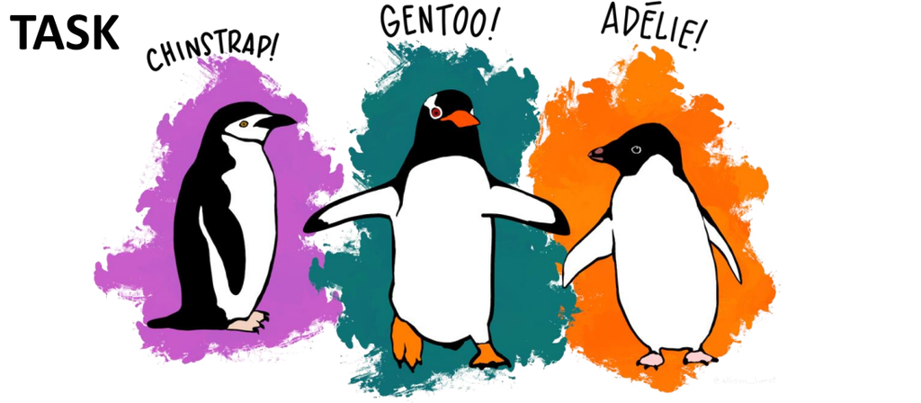

## Key details

- The Palmer penguins database includes body measurements from three different species of penguin from three islands in Antarctica
- The database is provided as an R package.
- You can download the database using: `install.packages("palmerpenguins")`
- You can then load in the package into your R work-space using:`library(palmerpenguins)`
- And view the data using: `head(penguins)`

### The variables

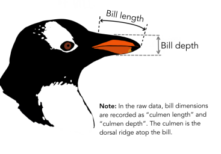

- The variables stored for the penguins are:
- species
- island
- bill_length_mm
- bill_depth_mm
- flipper_length_mm
- body_mass_g
- sex
- year

**Your turn!**

#### Group Assignment: Completing the R Notebook for Data Summarization

- **Instructions:**
- Work in groups to complete the template R Notebook [Data Summarization task](https://moodle.ucl.ac.uk/pluginfile.php/7179692/mod_resource/content/1/2%20-%20Summarising%20Data.Rmd). This task involves using R to produce summary statistics and plots.
- Add example code and appropriate comments for each heading provided in the Data Summarization task.
- Comments should explain when a statistic or plot is a good or bad choice.
- Choose examples that highlight the features of the Palmer Penguins dataset, allowing us to compare differences such as those between penguin species and gender.
- **Objective:**
- In this notebook, you will load the Palmer Penguins dataset and demonstrate how to use R for generating summary statistics and visualizations. Your goal is to elucidate the key features of the dataset and the distinctions between penguin species.
- **Steps:**
- Install the Necessary Package:
- To access the data, you need to install the palmerpenguins package. This is done by running `install.packages("palmerpenguins")` in the R console window. Note that this command is not included in the Notebook as it only needs to be executed once.

*Load the Data:*

- Use the appropriate R commands to load and explore the dataset.
- *Generate Summary Statistics:*
  - Provide code examples and comments for generating summary statistics such as mean, median, standard deviation, and others. Explain the suitability of each statistic for different types of data analysis.
- *Create Visualizations:*
  - Include example code and comments for creating plots such as histograms, boxplots, scatter plots, and more. Discuss when each type of plot is most useful and what insights it can provide.

**Resources:**

- You can refer to the complete model solution for this task [here](https://moodle.ucl.ac.uk/pluginfile.php/7179694/mod_resource/content/1/2c%20-%20Summarising%20Data.html).